# R Basics

## Overview

**This page is not intended to be a comprehensive “learn R” tutorial**. However, it does cover some fundamentals that can be useful for reference or for refreshing your memory. See the section on recommended training for links to more comprehensive tutorials.

Much of this page has been adapted with permission from the R Basics section of the [R4Epis project](https://r4epis.netlify.app/).

See the page on [Transition to R] for tips on switching to R from STATA, SAS, or Excel.

## Why use R?

As stated on the [R project website](https://www.r-project.org/about.html), R is a programming language and environment for statistical computing and graphics. It is highly versatile, extensible, and community-driven.

**Cost**

R is free to use! There is a strong ethic in the community of free and open-source material.

**Reproducibility**

Conducting your data management and analysis through a programming language (compared to Excel or another primarily point-click/manual tool) enhances **reproducibility**, makes **error-detection** easier, and eases your workload.

**Community**

The R community of users is enormous and collaborative. New packages and tools to address real-life problems are developed daily, and vetted by the community of users. As one example, [R-Ladies](https://rladies.org/) is a worldwide organization whose mission is to promote gender diversity in the R community, and is one of the largest organizations of R users. It likely has a chapter near you!

## Key terms

**RStudio** - RStudio is an interface (GUI) for easier use of **R**. Read more in this section.

**Objects** - Everything you store in R - datasets, variables, a list of village names, a total population number, even outputs such as graphs - are *objects* which are *assigned a name* and *can be referenced* in later commands. Read more in this section.

**Functions** - A function is a code operation that accept inputs and returns a transformed output. Read more in this section.

**Packages** - An R package is a shareable bundle of functions. Read more in this section.

**Scripts** - Scripts are the document files that hold your commands. Read more in this section

## Resources for learning

### Resources within RStudio

**Help documentation**

Search the RStudio “Help” tab for documentation on R packages and specific functions. This is within the pane that also contains Files, Plots, and Packages (typically in the lower-right pane). As a shortcut, you can also type the name of a package or function into the R console after a question-mark to open the relevant Help page. For example: `?filter` or `?diagrammeR`.

**Interactive tutorials**

RStudio has built-in interative tutorials via the **learnr** package. If this package is installed, you can go through these tutorials via the “Tutorial” tab in the upper-right RStudio pane (which also contains Environment and History tabs).

### Cheatsheets

There are many PDF “cheatsheets” available on the [RStudio website](https://rstudio.com/resources/cheatsheets/), for example:

- Factors with **forcats** package
- Dates and times with **lubridate** package
- Strings with **stringr** package
- “apply” functions with **purrr** package
- Data import cheatsheet
- Data transformation cheatsheet with **dplyr** package
- R Markdown
- Shiny
- Data visualization with **ggplot2** package
- Cartography
- **leaflet** package (interactive maps)
- Python with R (**reticulate** package)

This is an online R resource specifically for [Excel users](https://jules32.github.io/r-for-excel-users/)

### Twitter

R has a vibrant twitter community where you can learn tips, shortcuts, and news - follow these accounts:

- R Function A Day [@rfuntionaday](https://twitter.com/rfunctionaday) is an *incredible* resource
- R for Data Science [@rstats4ds](https://twitter.com/rstats4ds?lang=en)
- RStudio [@RStudio](https://twitter.com/rstudio?lang=en)
- RStudio Tips [@rstudiotips](https://twitter.com/rstudiotips)
- R-Bloggers [@Rbloggers](https://twitter.com/Rbloggers)
- R-ladies [@RLadiesGlobal](https://twitter.com/RLadiesGlobal)
- Hadley Wickham [@hadleywickham](https://twitter.com/hadleywickham?ref_src=twsrc%5Egoogle%7Ctwcamp%5Eserp%7Ctwgr%5Eauthor)

Also:

**#epitwitter** and **#rstats**

### Free online resources

A definitive text is the [R for Data Science](https://r4ds.had.co.nz/) book by Garrett Grolemund and Hadley Wickham

The [R4Epis](https://r4epis.netlify.app/) project website aims to “develop standardised data cleaning, analysis and reporting tools to cover common types of outbreaks and population-based surveys that would be conducted in an MSF emergency response setting.” You can find R basics training materials, templates for RMarkdown reports on outbreaks and surveys, and tutorials to help you set them up.

## Installation

**How to install R**

Visit this website https://www.r-project.org/ and download the latest version of R suitable for your computer.

**How to install RStudio**

Visit this website https://rstudio.com/products/rstudio/download/ and download the latest free Desktop version of RStudio suitable for your computer.

**Permissions**  
Note that you should install R and RStudio to a drive where you have read and write permissions. Otherwise, your ability to install R packages (a frequent occurrence) will be impacted. If you encounter problems, try opening RStudio by right-clicking the icon and selecting “Run as administrator”. Other tips can be found in the page [R on network drives].

**How to update R and RStudio**

Your version of R is printed to the R Console at start-up. You can also run `sessionInfo()`.

To update R, go to the website mentioned above and re-install R. Alternatively, you can use the **installr** package (on Windows) by running `installr::updateR()`. This will open dialog boxes to help you download the latest R version and update your packages to the new R version. More details can be found in the **installr** [documentation](https://www.r-project.org/nosvn/pandoc/installr.html).

Be aware that the old R version will still exist in your computer. You can temporarily run an older version (older “installation”) of R by clicking “Tools” -> “Global Options” in RStudio and choosing an R version. This can be useful if you want to use a package that has not been updated to work on the newest version of R.

To update RStudio, you can go to the website above and re-download RStudio. Another option is to click “Help” -> “Check for Updates” within RStudio, but this may not show the very latest updates.

To see which versions of R, RStudio, or packages were used when this Handbook as made, see the page on [Datasets and version used].

### Other software you *may* need to install

- TinyTeX (*for compiling an RMarkdown document to PDF*)
- Pandoc (*for compiling RMarkdown documents*)
- RTools (*for building packages for R*)
- phantomjs (*for saving still images of animated networks, such as transmission chains*)

#### TinyTex

TinyTex is a custom LaTeX distribution, useful when trying to produce PDFs from R.  
See https://yihui.org/tinytex/ for more informaton.

To install TinyTex from R:

```r
install.packages('tinytex')
tinytex::install_tinytex()
# to uninstall TinyTeX, run tinytex::uninstall_tinytex()
```

#### Pandoc

Pandoc is a document converter, a separate software from R. **It comes bundled with RStudio and should not need to be downloaded.** It helps the process of converting Rmarkdown documents to formats like .pdf and adding complex functionality.

#### RTools

RTools is a collection of software for building packages for R

Install from this website: https://cran.r-project.org/bin/windows/Rtools/

#### phantomjs

This is often used to take “screenshots” of webpages. For example when you make a transmission chain with **epicontacts** package, an HTML file is produced that is interactive and dynamic. If you want a static image, if can be useful to use the [**webshot**](https://wch.github.io/webshot/articles/intro.html) package to automate this process. This will require the external program “phantomjs”. You can install phantomjs via the **webshot** package with the command `webshot::install_phantomjs()`.

## RStudio

### RStudio Orientation

**First, open RStudio.** As their icons can look very similar, be sure you are opening *RStudio* and not R.

For RStudio to work you must also have R installed on the computer (see above for installation instructions).

**RStudio** is an interface (GUI) for easier use of **R**. You can think of R as being the engine of a vehicle, doing the crucial work, and RStudio as the body of the vehicle (with seats, accessories, etc.) that helps you actually use the engine to move forward! You can see the complete RStudio user-interface cheatsheet (PDF) [here](https://www.rstudio.com/wp-content/uploads/2016/01/rstudio-IDE-cheatsheet.pdf)

By default RStudio displays four rectangle panes.

*TIP:* If your RStudio displays only one left pane it is because you have no scripts open yet.

**The R Console Pane**

The R Console, by default the left or lower-left pane in R Studio, is the home of the R “engine”. This is where the commands are actually run and non-graphic outputs and error/warning messages appear. You can directly enter and run commands in the R Console, but realize that these commands are not saved as they are when running commands from a script.

If you are familiar with Stata, the R Console is like the Command Window and also the Results Window.

**The Source Pane**  
This pane, by default in the upper-left, is space to edit, run, and save your scripts, where you write your commands that you want to run. This pane can also display datasets (data frames) for viewing.

For Stata users, this pane is similar to your Do-file and Data Editor windows.

**The Environment Pane**  
This pane, by default the upper-right, is most often used to see brief summaries of objects in the R Environment in the current session. These objects could include imported, modified, or created datasets, parameters you have defined (e.g. a specific epi week for the analysis), or vectors or lists you have defined during analysis (e.g. names of regions). Click on the arrow next to a data frame name to see its variables.

In Stata, this is most similar to Variables Manager window.

This pane also contains *History* where can see commands that you can previously. It also has a “Tutorial” tab where you can complete interactive R tutorials if you have the **learnr** package installed. It also has a “Connections” pane for external connections, and can have a “Git” pane if you choose to interface with Github.

**Plots, Viewer, Packages, and Help Pane**  
The lower-right pane includes several tabs. Typical plot graphics including maps will display in the Plot pane. Interactive or HTML outputs will display in the Viewer pane. The Help pane can display documentation and help files. The Files pane is a browser which can be used to open or delete files. The Packages pane allows you to see, install, update, delete, load/unload R packages, and see which version of the package you have. To learn more about packages see the packages section below.

This pane contains the Stata equivalents of the Plots Manager and Project Manager windows.

### RStudio settings

Change RStudio settings and appearance in the *Tools* drop-down menu, by selecting *Global Options*. There you can change the default settings, including appearance/background color.

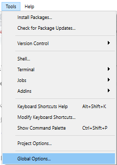

[figure not shown]

**Restart**

If your R freezes, you can re-start R by going to the Session menu and clicking “Restart R”. The avoids the hassle of closing and opening RStudio. Everything in your R environment will be removed when you do this.

### Keyboard shortcuts

Some very useful keyboard shortcuts are below. See all the keyboard shortcuts for Windows, Max, and Linux in the second page of this RStudio [user interface cheatsheet](https://www.rstudio.com/wp-content/uploads/2016/01/rstudio-IDE-cheatsheet.pdf).

| Windows/Linux | Mac | Action |
| --- | --- | --- |
| Esc | Esc | Interrupt current command (useful if you accidentally ran an incomplete command and cannot escape seeing “+” in the R console) |
| Ctrl + Enter | Cmd + Enter | Run current line(s)/selection of code |
| Ctrl + Shift + C | Cmd + Shift + c | comment/uncomment the highlighted lines |
| Alt + - | Option + - | Insert `<-` |
| Ctrl + Shift + m | Cmd + Shift + m | Insert `%>%` |
| Ctrl + l | Cmd + l | Clear the R console |
| Ctrl + Alt + b | Cmd + Option + b | Run from start to current line |
| Ctrl + Alt + t | Cmd + Option + t | Run the current code section (R Markdown) |
| Ctrl + Alt + i | Cmd + Shift + r | Insert code chunk (into R Markdown) |
| Ctrl + Alt + c | Cmd + Option + c | Run current code chunk (R Markdown) |
| Use your up and down arrows within R console | same | Toggle through recently run commands |
| Ctrl + f | Cmd + f | Find and replace in current script |
| Ctrl + Shift + f | Cmd + Shift + f | Find in files (search/replace across many scripts) |
| Alt + l | Cmd + Option + l | Fold selected code |
| Shift + Alt + l | Cmd + Shift + Option+l | Unfold selected code |

## Functions

Functions are at the core of using R. Functions are how you perform tasks and operations. Many functions come installed with R, many more are available for download in *packages* (explained in the next section), and you can even write your own custom functions!

This basics section on functions explains:

- What a function is and how they work
- What function *arguments* are
- How to get help understanding a function

*A quick note on syntax:* In this handbook, functions are written in code-text with open parentheses, like this: `filter()`. As explained in the packages section, functions are downloaded within *packages*. In this handbook, package names are written in **bold**, like **dplyr**. Sometimes in example code you may see the function name linked explicitly to the name of its package with two colons (`::`) like this: `dplyr::filter()`. The purpose of this linkage is explained in the packages section.

To learn about how to write functions, see the page Writing functions.

### Simple functions

**A function is like a machine that receives inputs, does some action with those inputs, and produces an output.** What the output is depends on the function.

**Functions typically operate upon some object placed within the function’s parentheses**. For example, the function `sqrt()` calculates the square root of a number:

```r
sqrt(49)
```

```
## [1] 7
```

The object provided to a function also can be a column in a dataset. Read the objects section for a detail on all the kinds of objects. For example, when the function `summary()` is applied to the numeric column `age` in the dataset `linelist`, the output is a summary of the columns’s numeric and missing values.

```r
summary(linelist$age)
```

```
##    Min. 1st Qu.  Median    Mean 3rd Qu.    Max.    NA's
##     0.0     6.0    13.0    16.1    23.0    84.0      86
```

*NOTE:* Behind the scenes, a function represents complex additional code that has been wrapped up for the user into one easy command.

### Functions with multiple arguments

Functions often ask for several inputs, called *arguments*, located within the parentheses of the function, usually separated by commas.

- Some arguments are required for the function to work correctly, others are optional
- Optional arguments have default settings
- Arguments can take character, numeric, logical (TRUE/FALSE), and other inputs

Here is a fun fictional function, called `oven_bake()`, as an example of a typical function. It takes an input object (e.g. a dataset, or in this example “dough”) and performs operations on it as specified by additional arguments (`minutes =` and `temperature =`). The output can be printed to the console, or saved as an object using the assignment operator `<-`.

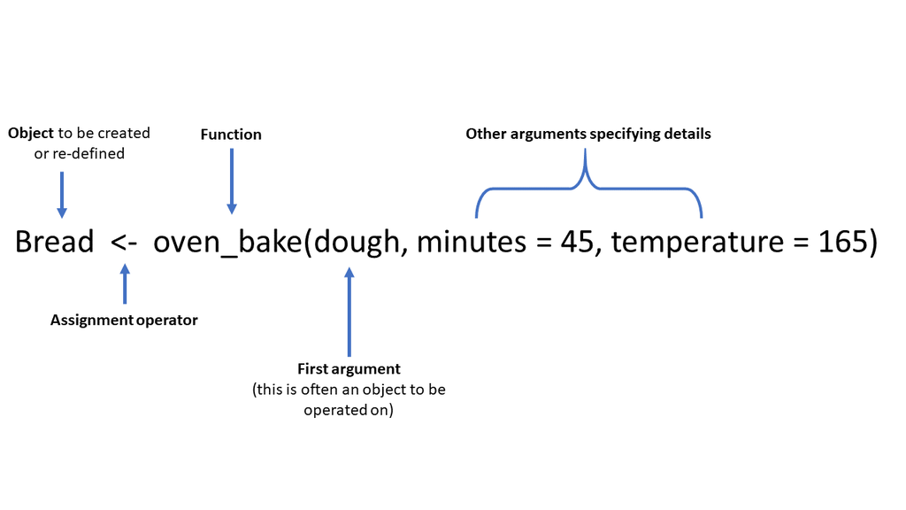

**In a more realistic example**, the `age_pyramid()` command below produces an age pyramid plot based on defined age groups and a binary split column, such as `gender`. The function is given three arguments within the parentheses, separated by commas. The values supplied to the arguments establish `linelist` as the dataframe to use, `age_cat5` as the column to count, and `gender` as the binary column to use for splitting the pyramid by color.

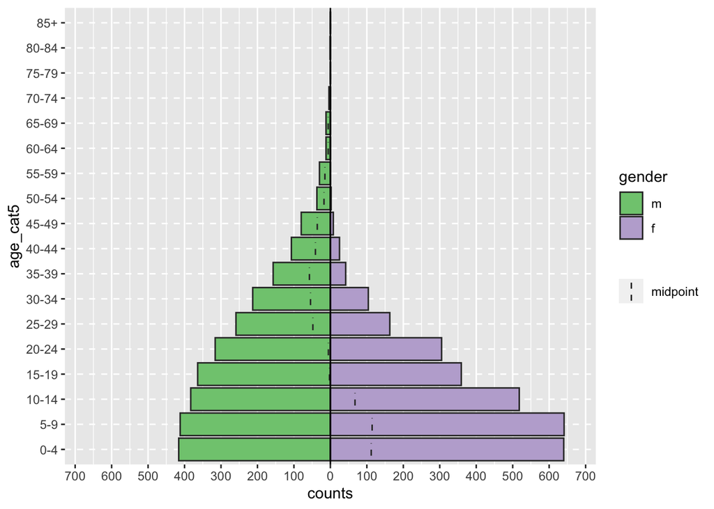

```r
# Create an age pyramid
age_pyramid(data = linelist, age_group = "age_cat5", split_by = "gender")
```

The above command can be equivalently written as below, with newlines. This can be easier to read and to write `# comments`. To run this command you can highlight the entire command and click “Run”, or just place your cursor in the first line and then press Ctrl and Enter keys simultaneously.

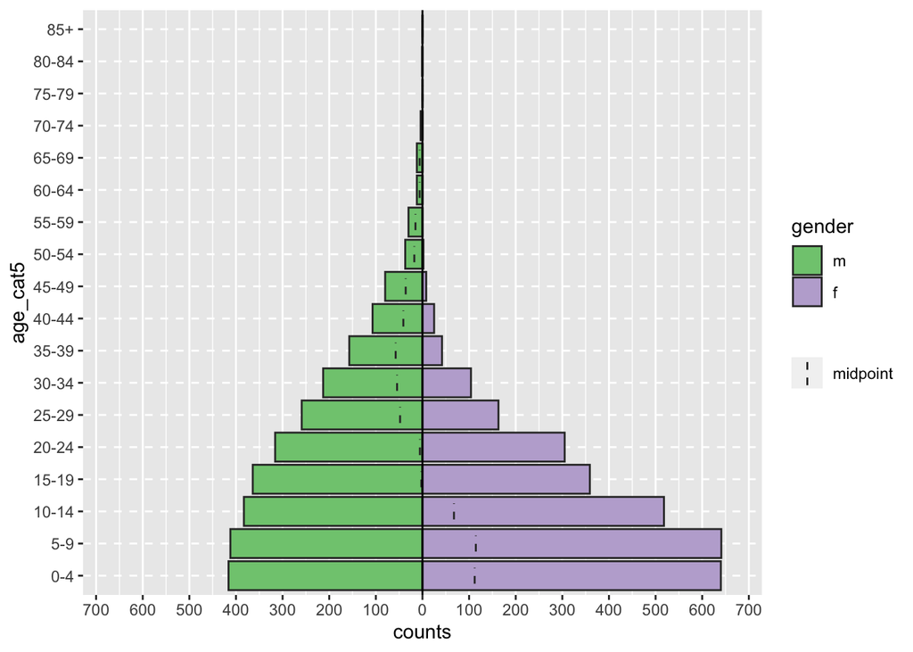

```r
# Create an age pyramid
age_pyramid(
  data = linelist,        # case linelist
  age_group = "age_cat5", # age group column
  split_by = "gender"     # two sides to pyramid
  )
```

The first half of an argument assignment (e.g. `data =`) does not need to be specified if the arguments are written in a specific order (specified in the function’s documentation). The below code produces the exact same pyramid as above, because the function expects the argument order: data frame, `age_group` variable, `split_by` variable.

```r
# This command will produce the exact same graphic as above
age_pyramid(linelist, "age_cat5", "gender")
```

**A more complex `age_pyramid()` command might include the *optional* arguments to:**

- Show proportions instead of counts (set `proportional = TRUE` when the default is `FALSE`)
- Specify the two colors to use (`pal =` is short for “palette” and is supplied with a vector of two color names. See the objects page for how the function `c()` makes a vector)

*NOTE:* For arguments that you specify with both parts of the argument (e.g. `proportional = TRUE`), their order among all the arguments does not matter.

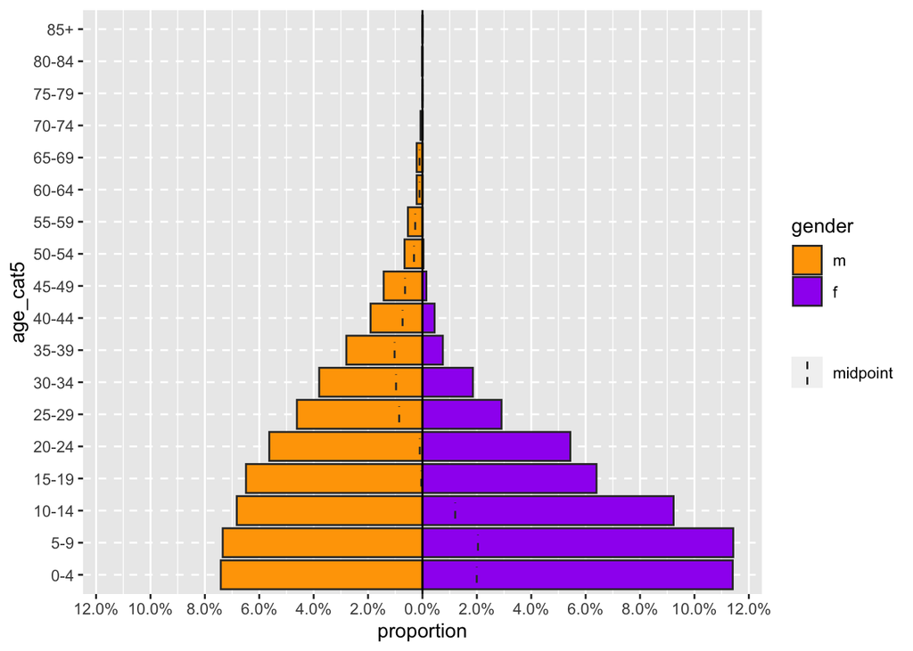

```r
age_pyramid(
  linelist,                    # use case linelist
  "age_cat5",                  # age group column
  "gender",                    # split by gender
  proportional = TRUE,         # percents instead of counts
  pal = c("orange", "purple")  # colors
  )
```

### Writing Functions

Writing your own functions is an incredibly useful skill, with many advantages:

- They facilitate modular programming, that is, they allow the separation of code in to independent and manageable pieces.
- With custom functions, you can give these pieces of code memorable names that are easy to interpret.
- They can also replace repetitive copy and pasting which can be error prone.

Using the previous toy example, to create the oven_bake function, the syntax may look something like this:

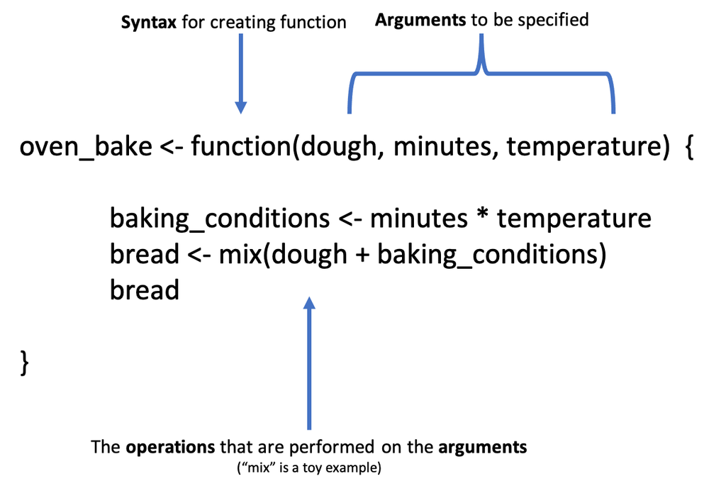

Here is an example of a real function, where we are simulating a staffing calculator for covid-19 contact tracing calls. The inputs, number_of_daily_covid_cases, call_length_per_case, call_length_per_contact and working_hours_per_day are used to calculate the number of staff required (per day) to make the calls. Defaults are set in the round brackets; the length of time to call a contact is 15 mins (0.25 hours), to call a case is 30 mins (0.5 hours) and the staff working day is 8 hours. In the curly brackets we perform the calculation:

```r
contact_tracing_staff_calculator <- function(daily_covid_cases, call_length_per_case = 0.5, call_length_per_contact = 0.25, working_hours_per_day = 8){ #the defaults are set in the round brackets

  case_hours <- daily_covid_cases * call_length_per_case
  contact_hours <- daily_covid_cases * call_length_per_contact

  staff_required <- (case_hours + contact_hours)/working_hours_per_day

  print(staff_required)


}
```

As the number of daily covid cases is not set in the function we must specify it when we call the function. To calculate the number of staff required if the number of daily covid cases is 5,500 the function is called as follows:

```r
contact_tracing_staff_calculator(daily_covid_cases = 5500)
```

```
## [1] 515.6
```

Writing functions is covered further in chapter 44, Writing functions.

## Packages

**Packages contain functions.**

An R package is a shareable bundle of code and documentation that contains pre-defined functions. Users in the R community develop and share packages all the time, so chances are likely that a solution exists for you! You will install and use hundreds of packages in your use of R.

On installation, R contains **“base”** packages and functions that perform common elementary tasks. But many R users create specialized functions, which are verified by the R community and which you can download as a **package** for your own use. In this handbook, package names are written in **bold**. One of the more challenging aspects of R is that there are often many functions or packages to choose from to complete a given task.

### Install and load

*Functions* are contained within **packages** which can be downloaded (“installed”) to your computer from the internet. Once a package is downloaded, you can access its functions during your current R session by loading the package with the `library()` command (from **base** R) at the beginning of each R session. In this handbook, we advocate for use of `p_load()` instead of `library()`, but `library()` is still a very common approach.

*Think of R as your personal library*: When you download a package, your library gains a new book of functions, but each time you want to use a function in that book, you must borrow that book from your library.

**Your library**

Your “library” is actually a folder on your computer, containing a folder for each package that has been installed. Find out where R is installed in your computer, and look for a folder called “win-library”. For example: `R\win-library\4.0` (the 4.0 is the R version - you’ll have a different library for each R version you’ve downloaded). As a last-case measure, you can remove a package by manually deleting it from here (but it is better to use `remove.packages("packagename")`).

**CRAN**

CRAN (Comprehensive R Archive Network) is a public warehouse of R packages that have been published by R community members. Most often, R users download packages from CRAN.

**Install vs. Load**

To use a package, 2 steps must be implemented:

1. The package must be **installed** (once), *and*
2. The package must be **loaded** (each R session)

The **base** R function for installing a package is `install.packages()`, where the name of the package is provided *in quotes*. This can also be accomplished point-and-click by going to the RStudio “Packages” pane and clicking “Install” and typing the package name. Note all this is case-sensitive.

```r
install.packages("tidyverse")
```

The basic function to **load** a package for use (after it has been installed) is `library()`, with the name of the package *NOT in quotes*.

```r
library(tidyverse)
```

To check whether a package in installed or loaded, you can view the Packages pane in RStudio. If the package is installed, it is shown there with version number. If the box is checked, it is loaded for the current session.

**We suggest using pacman**

This handbook emphasizes use of the package **pacman** (abbreviation for “package manager”), which offers the useful function `p_load()`. **This function combines the above two steps into one - it *installs and/or loads packages*, depending on what is needed.** If the package has not yet been installed, it will attempt to install from CRAN, and then will load it for use. This is really useful if sharing your script with someone else who may not have all the packages.

Below, we use `p_load()` on three packages often used in this handbook. Note that we have used the syntax `pacman::p_load()` which explicitly writes the package name prior to the function name, connected by two colons `::`. This syntax is useful in that it also functions to load the package (**pacman** in this case), so this command can stand alone at the top of your script. You do not need to load **pacman** before running this command to load the other three packages.

```r
pacman::p_load(tidyverse, rio, here)
```

**Install from Github**

Sometimes, you need to install a package that is not yet available from CRAN. Or perhaps the package is available on CRAN but you want the *development version* with new features not yet offered in the more stable published CRAN version. These are often hosted on the website Github in a public-facing code “repository”.

To download these packages, you can use `p_load_gh()` from **pacman**. You may also see guidance to use the **remotes** or **devtools** packages. In the background, this **pacman** function utilizes `install_github()` from **devtools**.

To install from github, you have to provide different information to the function. You must provide the Github ID of the repository owner, and the name of the code repository which contains the package.

In the examples below, the first name listed in the quotation marks is the Github ID of the repository owner, and after the slash is the name of the repository. If you want to install from a branch other than the main/master branch, add the branch name after an “@” after the repository name.

```r
# install/load package from github repository
p_load_gh("reconhub/epicontacts")

# load development version of package which you had downloaded from github repository
p_load_gh("reconhub/epicontacts")

# install development version of package, but not the main branch
p_install_gh("reconhub/epicontacts@timeline")
```

Read more about **pacman** in this [online vignette](http://trinker.github.io/pacman/vignettes/Introduction_to_pacman.html)

**Install from ZIP or TAR**

You could install the package from a URL:

```r
packageurl <- "https://cran.r-project.org/src/contrib/Archive/dsr/dsr_0.2.2.tar.gz"
install.packages(packageurl, repos=NULL, type="source")
```

Or, download it to your computer in a zipped file:

Option 1: using `install_local()` from the **remotes** package

```r
remotes::install_local("~/Downloads/dplyr-master.zip")
```

Option 2: using `install.packages()` from **base** R, providing the file path to the ZIP file and setting `type = "source` and `repos = NULL`.

```r
install.packages("~/Downloads/dplyr-master.zip", repos=NULL, type="source")
```

### Code syntax

For clarity in this handbook, functions are sometimes preceded by the name of their package using the `::` symbol in the following way: `package_name::function_name()`

Once a package is loaded for a session, this explicit style is not necessary. One can just use `function_name()`. However writing the package name is useful when a function name is common and may exist in multiple packages (e.g. `plot()`). Writing the package name will also load the package if it is not already loaded.

```r
# This command uses the package "rio" and its function "import()" to import a dataset
linelist <- rio::import("linelist.xlsx", which = "Sheet1")
```

### Function help

To read more about a function, you can search for it in the Help tab of the lower-right RStudio. You can also run a command like `?thefunctionname` (put the name of the function after a question mark) and the Help page will appear in the Help pane. Finally, try searching online for resources.

### Update packages

You can update packages by re-installing them. You can also click the green “Update” button in your RStudio Packages pane to see which packages have new versions to install. Be aware that your old code may need to be updated if there is a major revision to how a function works!

### Delete packages

Use `p_delete()` from **pacman**, or `remove.packages()` from **base** R. Alternatively, go find the folder which contains your library and manually delete the folder.

### Dependencies

Packages often depend on other packages to work. These are called dependencies. If a dependency fails to install, then the package depending on it may also fail to install.

See the dependencies of a package with `p_depends()`, and see which packages depend on it with `p_depends_reverse()`

### Masked functions

It is not uncommon that two or more packages contain the same function name. For example, the package **dplyr** has a `filter()` function, but so does the package **stats**. The default `filter()` function depends on the order these packages are first loaded in the R session - the later one will be the default for the command `filter()`.

You can check the order in your Environment pane of R Studio - click the drop-down for “Global Environment” and see the order of the packages. Functions from packages *lower* on that drop-down list will mask functions of the same name in packages that appear higher in the drop-down list. When first loading a package, R will warn you in the console if masking is occurring, but this can be easy to miss.

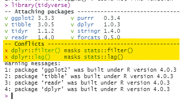

Here are ways you can fix masking:

1. Specify the package name in the command. For example, use `dplyr::filter()`
2. Re-arrange the order in which the packages are loaded (e.g. within `p_load()`), and **start a new R session**

### Detach / unload

To detach (unload) a package, use this command, with the correct package name and only one colon. Note that this may not resolve masking.

```r
detach(package:PACKAGE_NAME_HERE, unload=TRUE)
```

### Install older version

See this [guide](https://support.rstudio.com/hc/en-us/articles/219949047-Installing-older-versions-of-packages) to install an older version of a particular package.

### Suggested packages

See the page on Suggested packages for a listing of packages we recommend for everyday epidemiology.

## Scripts

Scripts are a fundamental part of programming. They are documents that hold your commands (e.g. functions to create and modify datasets, print visualizations, etc). You can save a script and run it again later. There are many advantages to storing and running your commands from a script (vs. typing commands one-by-one into the R console “command line”):

- Portability - you can share your work with others by sending them your scripts
- Reproducibility - so that you and others know exactly what you did
- Version control - so you can track changes made by yourself or colleagues
- Commenting/annotation - to explain to your colleagues what you have done

### Commenting

In a script you can also annotate (“comment”) around your R code. Commenting is helpful to explain to yourself and other readers what you are doing. You can add a comment by typing the hash symbol (#) and writing your comment after it. The commented text should appear in a different color than the R code. Any code written after the # will not be run. Therefore, placing a # before code is a useful way to temporarily not run a line of code (perhaps you do not want to run the line, but also do not want to delete it).

```r
# A comment can be on a line by itself
# import data
linelist <- import("linelist_raw.xlsx")  # a comment can also come after code
```

### Style

It is important to be conscious of your coding style - especially if working on a team. We advocate for the **tidyverse** [style guide](https://style.tidyverse.org/). There are also packages such as **styler** and **lintr** which help you conform to this style.

A few very basic points to make your code readable to others:  
* When naming objects, use only lowercase letters, numbers, and underscores `_`, e.g. `my_data`  
* Use frequent spaces, including around operators, e.g. `n = 1` and `age_new <- age_old + 3`

### Example Script

Below is an example of a short R script. Remember, the better you succinctly explain your code in comments, the more your colleagues will like you!

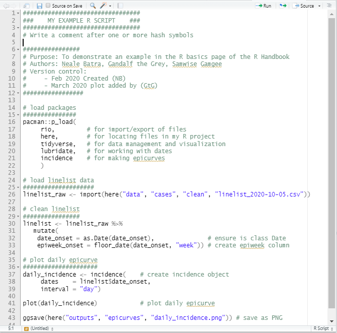

### R markdown

An R markdown script is a type of R script in which the script itself *becomes* an output document (PDF, Word, HTML, Powerpoint, etc.). These are incredibly useful and versatile tools often used to create dynamic and automated reports. Even this website and handbook is produced with R markdown scripts!

To learn more, see the handbook page on [R Markdown reports] documents.

### R notebooks

There is no difference between writing in a Rmarkdown vs an R notebook. However the execution of the document differs slightly. See this [site](http://uc-r.github.io/r_notebook) for more details.

### Shiny

Shiny apps/websites are contained within one script, which must be named `app.R`. This file has three components:

1. A user interface (ui)
2. A server function
3. A call to the `shinyApp` function

See the handbook page on [Dashboards with Shiny], or this online tutorial: [Shiny tutorial](https://shiny.rstudio.com/tutorial/written-tutorial/lesson1/)

*In older times, the above file was split into two files (`ui.R` and `server.R`)*

### Code folding

You can collapse portions of code to make your script easier to read.

To do this, create a text header with #, write your header, and follow it with at least 4 of either dashes (-), hashes (#) or equals (=). When you have done this, a small arrow will appear in the “gutter” to the left (by the row number). You can click this arrow and the code below until the next header will collapse and a dual-arrow icon will appear in its place.

To expand the code, either click the arrow in the gutter again, or the dual-arrow icon. There are also keyboard shortcuts as explained in the RStudio section of this page.

By creating headers with #, you will also activate the Table of Contents at the bottom of your script (see below) that you can use to navigate your script. You can create sub-headers by adding more # symbols, for example # for primary, ## for seconary, and ### for tertiary headers.

Below are two versions of an example script. On the left is the original with commented headers. On the right, four dashes have been written after each header, making them collapsible. Two of them have been collapsed, and you can see that the Table of Contents at the bottom now shows each section.

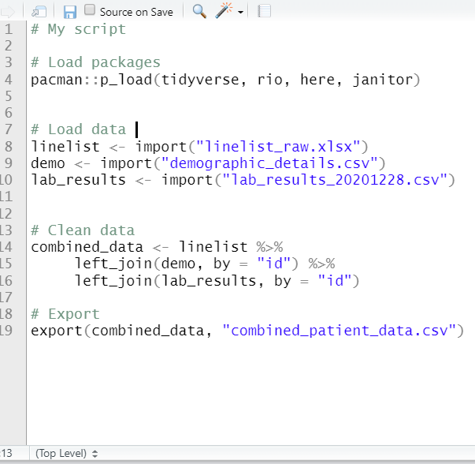

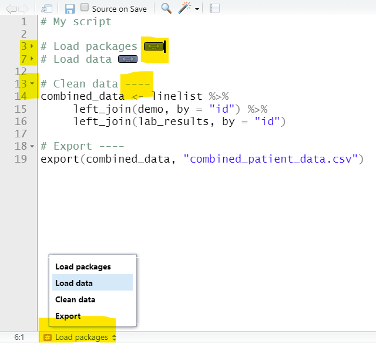

Other areas of code that are automatically eligible for folding include “braced” regions with brackets `{ }` such as function definitions or conditional blocks (if else statements). You can read more about code folding at the RStudio [site](https://support.rstudio.com/hc/en-us/articles/200484568-Code-Folding-and-Sections).

## Working directory

The working directory is the root folder location used by R for your work - where R looks for and saves files by default. By default, it will save new files and outputs to this location, and will look for files to import (e.g. datasets) here as well.

The working directory appears in grey text at the top of the RStudio Console pane. You can also print the current working directory by running `getwd()` (leave the parentheses empty).

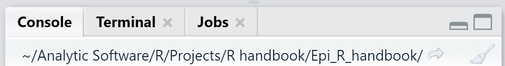

### Recommended approach

**See the page on [R projects] for details on our recommended approach to managing your working directory.**  
A common, efficient, and trouble-free way to manage your working directory and file paths is to combine these 3 elements:

1. A R Project to store all your files
2. The **here** package to locate files
3. The **rio** package to import/export files

### Set by command

Although we do not recommend this approach in most circumstances, you can use the command `setwd()` with the desired folder file path in quotations, for example:

```r
setwd("C:/Documents/R Files/My analysis")
```

*DANGER:* Setting a working directory with `setwd()` *can* be “brittle” if the file path is specific to one computer. Instead, use file paths relative to a R Project root directory (with the **here** package).

### Set manually

To set the working directory manually (the point-and-click equivalent of `setwd()`), click the Session drop-down menu and go to “Set Working Directory” and then “Choose Directory”. This will set the working directory for that specific R session. Note: if using this approach, you will have to do this manually each time you open RStudio.

### Within an R project

If using an R project, the working directory will default to the R project root folder that contains the “.rproj” file. This will apply if you open RStudio by clicking open the R Project (the file with “.rproj” extension).

### Working directory in an R markdown

In an R markdown script, the default working directory is the folder the Rmarkdown file (`.Rmd`) is saved within. If using an R project and **here** package, this does not apply and the working directory will be `here()` as explained in the [R projects] page.

If you want to change the working directory of a stand-alone R markdown (not in an R project), if you use `setwd()` this will only apply to that specific code chunk. To make the change for all code chunks in an R markdown, edit the setup chunk to add the `root.dir =` parameter, such as below:

```r
knitr::opts_knit$set(root.dir = 'desired/directorypath')
```

It is much easier to just use the R markdown within an R project and use the **here** package.

### Providing file paths

Perhaps the most common source of frustration for an R beginner (at least on a Windows machine) is typing in a file path to import or export data. There is a thorough explanation of how to best input file paths in the [Import and export] page, but here are a few key points:

**Broken paths**

Below is an example of an “absolute” or “full address” file path. These will likely break if used by another computer. One exception is if you are using a shared/network drive.

```
C:/Users/Name/Document/Analytic Software/R/Projects/Analysis2019/data/March2019.csv
```

**Slash direction**

*If typing in a file path, be aware the direction of the slashes.* Use *forward slashes* (`/`) to separate the components (“data/provincial.csv”). For Windows users, the default way that file paths are displayed is with *back slashes* (\) - so you will need to change the direction of each slash. If you use the **here** package as described in the [R projects] page the slash direction is not an issue.

**Relative file paths**

We generally recommend providing “relative” filepaths instead - that is, the path *relative to* the root of your R Project. You can do this using the **here** package as explained in the [R projects] page. A relativel filepath might look like this:

```r
# Import csv linelist from the data/linelist/clean/ sub-folders of a R project
linelist <- import(here("data", "clean", "linelists", "marin_country.csv"))
```

Even if using relative file paths within an R project, you can still use absolute paths to import/export data outside your R project.

## Objects

Everything in R is an object, and R is an “object-oriented” language. These sections will explain:

- How to create objects (`<-`)
- Types of objects (e.g. data frames, vectors..)
- How to access subparts of objects (e.g. variables in a dataset)
- Classes of objects (e.g. numeric, logical, integer, double, character, factor)

### Everything is an object

*This section is adapted from the [R4Epis project](https://r4epis.netlify.app/training/r_basics/objects/).*  
Everything you store in R - datasets, variables, a list of village names, a total population number, even outputs such as graphs - are **objects** which are **assigned a name** and **can be referenced** in later commands.

An object exists when you have assigned it a value (see the assignment section below). When it is assigned a value, the object appears in the Environment (see the upper right pane of RStudio). It can then be operated upon, manipulated, changed, and re-defined.

### Defining objects (`<-`)

**Create objects *by assigning them a value* with the <- operator.**  
You can think of the assignment operator `<-` as the words “is defined as”. Assignment commands generally follow a standard order:

**object_name** <- **value** (or process/calculation that produce a value)

For example, you may want to record the current epidemiological reporting week as an object for reference in later code. In this example, the object `current_week` is created when it is assigned the character value `"2018-W10"` (the quote marks make these a character value). The object `current_week` will then appear in the RStudio Environment pane (upper-right) and can be referenced in later commands.

See the R commands and their output in the boxes below.

```r
current_week <- "2018-W10"   # this command creates the object current_week by assigning it a value
current_week                 # this command prints the current value of current_week object in the console
```

```
## [1] "2018-W10"
```

*NOTE:* Note the `[1]` in the R console output is simply indicating that you are viewing the first item of the output

*CAUTION:* **An object’s value can be over-written** at any time by running an assignment command to re-define its value. Thus, the **order of the commands run is very important**.

The following command will re-define the value of `current_week`:

```r
current_week <- "2018-W51"   # assigns a NEW value to the object current_week
current_week                 # prints the current value of current_week in the console
```

```
## [1] "2018-W51"
```

**Equals signs `=`**

You will also see equals signs in R code:

- A double equals sign `==` between two objects or values asks a logical *question*: “is this equal to that?”.
- You will also see equals signs within functions used to specify values of function arguments (read about these in sections below), for example `max(age, na.rm = TRUE)`.
- You *can* use a single equals sign `=` in place of `<-` to create and define objects, but this is discouraged. You can about why this is discouraged [here](https://renkun.me/2014/01/28/difference-between-assignment-operators-in-r/).

**Datasets**

Datasets are also objects (typically “dataframes”) and must be assigned names when they are imported. In the code below, the object `linelist` is created and assigned the value of a CSV file imported with the **rio** package and its `import()` function.

```r
# linelist is created and assigned the value of the imported CSV file
linelist <- import("my_linelist.csv")
```

You can read more about importing and exporting datasets with the section on [Import and export].

*CAUTION:* A quick note on naming of objects:

- Object names must not contain spaces, but you should use underscore (_) or a period (.) instead of a space.
- Object names are case-sensitive (meaning that Dataset_A is different from dataset_A).
- Object names must begin with a letter (cannot begin with a number like 1, 2 or 3).

**Outputs**

Outputs like tables and plots provide an example of how outputs can be saved as objects, or just be printed without being saved. A cross-tabulation of gender and outcome using the **base** R function `table()` can be printed directly to the R console (*without* being saved).

```r
# printed to R console only
table(linelist$gender, linelist$outcome)
```

```
##
##     Death Recover
##   f  1227     953
##   m  1228     950
```

But the same table can be saved as a named object. Then, optionally, it can be printed.

```r
# save
gen_out_table <- table(linelist$gender, linelist$outcome)

# print
gen_out_table
```

```
##
##     Death Recover
##   f  1227     953
##   m  1228     950
```

**Columns**

Columns in a dataset are also objects and can be defined, over-written, and created as described below in the section on Columns.

You can use the assignment operator from **base** R to create a new column. Below, the new column `bmi` (Body Mass Index) is created, and for each row the new value is result of a mathematical operation on the row’s value in the `wt_kg` and `ht_cm` columns.

```r
# create new "bmi" column using base R syntax
linelist$bmi <- linelist$wt_kg / (linelist$ht_cm/100)^2
```

However, in this handbook, we emphasize a different approach to defining columns, which uses the function `mutate()` from the **dplyr** package and *piping* with the pipe operator (`%>%`). The syntax is easier to read and there are other advantages explained in the page on [Cleaning data and core functions]. You can read more about *piping* in the Piping section below.

```r
# create new "bmi" column using dplyr syntax
linelist <- linelist %>%
  mutate(bmi = wt_kg / (ht_cm/100)^2)
```

### Object structure

**Objects can be a single piece of data (e.g. `my_number <- 24`), or they can consist of structured data.**

In epidemiology (and particularly field epidemiology), you will *most commonly* encounter data frames and vectors:

| Common structure | Explanation | Example |
| --- | --- | --- |
| Vectors | A container for a sequence of singular objects, all of the same class (e.g. numeric, character). | **“Variables” (columns) in data frames are vectors** (e.g. the column `age_years`). |
| Data Frames | Vectors (e.g. columns) that are bound together that all have the same number of rows. | `linelist` is a data frame. |

Note that to create a vector that “stands alone” (is not part of a data frame) the function `c()` is used to combine the different elements. For example, if creating a vector of colors plot’s color scale: `vector_of_colors <- c("blue", "red2", "orange", "grey")`

### Object classes

All the objects stored in R have a *class* which tells R how to handle the object. There are many possible classes, but common ones include:

| Class | Explanation | Examples |
| --- | --- | --- |
| Character | These are text/words/sentences **“within quotation marks”**. Math cannot be done on these objects. | “Character objects are in quotation marks” |
| Integer | Numbers that are **whole only** (no decimals) | -5, 14, or 2000 |
| Numeric | These are numbers and **can include decimals**. If within quotation marks the will be considered character. | 23.1 or 14 |
| Factor | These are vectors that have a **specified order** or hierarchy of values | An variable of economic status with ordered values |
| Date | **Once R is told that certain data are Dates**, these data can be manipulated and displayed in special ways. See the page on [Working with dates] for more information. | 2018-04-12 or 15/3/1954 or Wed 4 Jan 1980 |
| Logical | Values must be one of the two special values TRUE or FALSE (note these are **not** “TRUE” and “FALSE” in quotation marks) | TRUE or FALSE |
| data.frame | A data frame is how R stores a **typical dataset**. It consists of vectors (columns) of data bound together, that all have the same number of observations (rows). | The example AJS dataset named `linelist_raw` contains 68 variables with 300 observations (rows) each. |
| tibble | tibbles are a variation on data frame, the main operational difference being that they print more nicely to the console (display first 10 rows and only columns that fit on the screen) | Any data frame, list, or matrix can be converted to a tibble with `as_tibble()` |
| list | A list is like vector, but holds other objects that can be other different classes | A list could hold a single number, and a dataframe, and a vector, and even another list within it! |

**You can test the class of an object by providing its name to the function `class()`**. Note: you can reference a specific column within a dataset using the `$` notation to separate the name of the dataset and the name of the column.

```r
class(linelist)         # class should be a data frame or tibble
```

```
## [1] "data.frame"
```

```r
class(linelist$age)     # class should be numeric
```

```
## [1] "numeric"
```

```r
class(linelist$gender)  # class should be character
```

```
## [1] "character"
```

Sometimes, a column will be converted to a different class automatically by R. Watch out for this! For example, if you have a vector or column of numbers, but a character value is inserted… the entire column will change to class character.

```r
num_vector <- c(1,2,3,4,5) # define vector as all numbers
class(num_vector)          # vector is numeric class
```

```
## [1] "numeric"
```

```r
num_vector[3] <- "three"   # convert the third element to a character
class(num_vector)          # vector is now character class
```

```
## [1] "character"
```

One common example of this is when manipulating a data frame in order to print a table - if you make a total row and try paste/glue together percents in the same cell as numbers (e.g. `23 (40%)`), the entire numeric column above will convert to character and can no longer be used for mathematical calculations.**Sometimes, you will need to convert objects or columns to another class.**

| Function | Action |
| --- | --- |
| `as.character()` | Converts to character class |
| `as.numeric()` | Converts to numeric class |
| `as.integer()` | Converts to integer class |
| `as.Date()` | Converts to Date class - Note: see section on dates for details |
| `factor()` | Converts to factor - Note: re-defining order of value levels requires extra arguments |

Likewise, there are **base** R functions to check whether an object IS of a specific class, such as `is.numeric()`, `is.character()`, `is.double()`, `is.factor()`, `is.integer()`

Here is [more online material on classes and data structures in R](https://swcarpentry.github.io/r-novice-inflammation/13-supp-data-structures/).

### Columns/Variables (`$`)

**A column in a data frame is technically a “vector” (see table above)** - a series of values that must all be the same class (either character, numeric, logical, etc).

A vector can exist independent of a data frame, for example a vector of column names that you want to include as explanatory variables in a model. To create a “stand alone” vector, use the `c()` function as below:

```r
# define the stand-alone vector of character values
explanatory_vars <- c("gender", "fever", "chills", "cough", "aches", "vomit")

# print the values in this named vector
explanatory_vars
```

```
## [1] "gender" "fever"  "chills" "cough"  "aches"  "vomit"
```

**Columns in a data frame are also vectors and can be called, referenced, extracted, or created using the `$` symbol.** The `$` symbol connects the name of the column to the name of its data frame. In this handbook, we try to use the word “column” instead of “variable”.

```r
# Retrieve the length of the vector age_years
length(linelist$age) # (age is a column in the linelist data frame)
```

By typing the name of the dataframe followed by `$` you will also see a drop-down menu of all columns in the data frame. You can scroll through them using your arrow key, select one with your Enter key, and avoid spelling mistakes!

[figure not shown]

*ADVANCED TIP:* Some more complex objects (e.g. a list, or an `epicontacts` object) may have multiple levels which can be accessed through multiple dollar signs. For example `epicontacts$linelist$date_onset`

### Access/index with brackets (`[ ]`)

You may need to view parts of objects, also called “indexing”, which is often done using the square brackets `[ ]`. Using `$` on a dataframe to access a column is also a type of indexing.

```r
my_vector <- c("a", "b", "c", "d", "e", "f")  # define the vector
my_vector[5]                                  # print the 5th element
```

```
## [1] "e"
```

Square brackets also work to return specific parts of an returned output, such as the output of a `summary()` function:

```r
# All of the summary
summary(linelist$age)
```

```
##    Min. 1st Qu.  Median    Mean 3rd Qu.    Max.    NA's
##     0.0     6.0    13.0    16.1    23.0    84.0      86
```

```r
# Just the second element of the summary, with name (using only single brackets)
summary(linelist$age)[2]
```

```
## 1st Qu.
##       6
```

```r
# Just the second element, without name (using double brackets)
summary(linelist$age)[[2]]
```

```
## [1] 6
```

```r
# Extract an element by name, without showing the name
summary(linelist$age)[["Median"]]
```

```
## [1] 13
```

Brackets also work on data frames to view specific rows and columns. You can do this using the syntax `dataframe[rows, columns]`:

```r
# View a specific row (2) from dataset, with all columns (don't forget the comma!)
linelist[2,]

# View all rows, but just one column
linelist[, "date_onset"]

# View values from row 2 and columns 5 through 10
linelist[2, 5:10]

# View values from row 2 and columns 5 through 10 and 18
linelist[2, c(5:10, 18)]

# View rows 2 through 20, and specific columns
linelist[2:20, c("date_onset", "outcome", "age")]

# View rows and columns based on criteria
# *** Note the dataframe must still be named in the criteria!
linelist[linelist$age > 25 , c("date_onset", "outcome", "age")]

# Use View() to see the outputs in the RStudio Viewer pane (easier to read)
# *** Note the capital "V" in View() function
View(linelist[2:20, "date_onset"])

# Save as a new object
new_table <- linelist[2:20, c("date_onset")]
```

Note that you can also achieve the above row/column indexing on data frames and tibbles using **dplyr** syntax (functions `filter()` for rows, and `select()` for columns). Read more about these core functions in the [Cleaning data and core functions] page.

To filter based on “row number”, you can use the **dplyr** function `row_number()` with open parentheses as part of a logical filtering statement. Often you will use the `%in%` operator and a range of numbers as part of that logical statement, as shown below. To see the *first* N rows, you can also use the special **dplyr** function `head()`.

```r
# View first 100 rows
linelist %>% head(100)

# Show row 5 only
linelist %>% filter(row_number() == 5)

# View rows 2 through 20, and three specific columns (note no quotes necessary on column names)
linelist %>% filter(row_number() %in% 2:20) %>% select(date_onset, outcome, age)
```

When indexing an object of class **list**, single brackets always return with class list, even if only a single object is returned. Double brackets, however, can be used to access a single element and return a different class than list.  
Brackets can also be written after one another, as demonstrated below.

This [visual explanation of lists indexing, with pepper shakers](https://r4ds.had.co.nz/vectors.html#lists-of-condiments) is humorous and helpful.

```r
# define demo list
my_list <- list(
  # First element in the list is a character vector
  hospitals = c("Central", "Empire", "Santa Anna"),

  # second element in the list is a data frame of addresses
  addresses   = data.frame(
    street = c("145 Medical Way", "1048 Brown Ave", "999 El Camino"),
    city   = c("Andover", "Hamilton", "El Paso")
    )
  )
```

Here is how the list looks when printed to the console. See how there are two named elements:

- `hospitals`, a character vector
- `addresses`, a data frame of addresses

```r
my_list
```

```
## $hospitals
## [1] "Central"    "Empire"     "Santa Anna"
##
## $addresses
##            street     city
## 1 145 Medical Way  Andover
## 2  1048 Brown Ave Hamilton
## 3   999 El Camino  El Paso
```

Now we extract, using various methods:

```r
my_list[1] # this returns the element in class "list" - the element name is still displayed
```

```
## $hospitals
## [1] "Central"    "Empire"     "Santa Anna"
```

```r
my_list[[1]] # this returns only the (unnamed) character vector
```

```
## [1] "Central"    "Empire"     "Santa Anna"
```

```r
my_list[["hospitals"]] # you can also index by name of the list element
```

```
## [1] "Central"    "Empire"     "Santa Anna"
```

```r
my_list[[1]][3] # this returns the third element of the "hospitals" character vector
```

```
## [1] "Santa Anna"
```

```r
my_list[[2]][1] # This returns the first column ("street") of the address data frame
```

```
##            street
## 1 145 Medical Way
## 2  1048 Brown Ave
## 3   999 El Camino
```

### Remove objects

You can remove individual objects from your R environment by putting the name in the `rm()` function (no quote marks):

```r
rm(object_name)
```

You can remove all objects (clear your workspace) by running:

```r
rm(list = ls(all = TRUE))
```

## Piping (`%>%`)

**Two general approaches to working with objects are:**

1. **Pipes/tidyverse** - pipes send an object from function to function - emphasis is on the *action*, not the object
2. **Define intermediate objects** - an object is re-defined again and again - emphasis is on the object

### **Pipes**

**Simply explained, the pipe operator (`%>%`) passes an intermediate output from one function to the next.**  
You can think of it as saying “then”. Many functions can be linked together with `%>%`.

- **Piping emphasizes a sequence of actions, not the object the actions are being performed on**
- Pipes are best when a sequence of actions must be performed on one object
- Pipes come from the package **magrittr**, which is automatically included in packages **dplyr** and **tidyverse**
- Pipes can make code more clean and easier to read, more intuitive

Read more on this approach in the tidyverse [style guide](https://style.tidyverse.org/pipes.html)

Here is a fake example for comparison, using fictional functions to “bake a cake”. First, the pipe method:

```r
# A fake example of how to bake a care using piping syntax

cake <- flour %>%       # to define cake, start with flour, and then...
  left_join(eggs) %>%   # add eggs
  left_join(oil) %>%    # add oil
  left_join(water) %>%  # add water
  mix_together(         # mix together
    utensil = spoon,
    minutes = 2) %>%
  bake(degrees = 350,   # bake
       system = "fahrenheit",
       minutes = 35) %>%
  let_cool()            # let it cool down
```

Here is another [link](https://cfss.uchicago.edu/notes/pipes/#:~:text=Pipes%20are%20an%20extremely%20useful,code%20and%20combine%20multiple%20operations) describing the utility of pipes.

Piping is not a **base** function. To use piping, the **magrittr** package must be installed and loaded (this is typically done by loading **tidyverse** or **dplyr** package which include it). You can [read more about piping in the magrittr documentation](https://magrittr.tidyverse.org/).

Note that just like other R commands, pipes can be used to just display the result, or to save/re-save an object, depending on whether the assignment operator `<-` is involved. See both below:

```r
# Create or overwrite object, defining as aggregate counts by age category (not printed)
linelist_summary <- linelist %>%
  count(age_cat)
```

```r
# Print the table of counts in the console, but don't save it
linelist %>%
  count(age_cat)
```

```
##   age_cat    n
## 1     0-4 1095
## 2     5-9 1095
## 3   10-14  941
## 4   15-19  743
## 5   20-29 1073
## 6   30-49  754
## 7   50-69   95
## 8     70+    6
## 9    <NA>   86
```

**`%<>%`**  
This is an “assignment pipe” from the **magrittr** package, which *pipes an object forward and also re-defines the object*. It must be the first pipe operator in the chain. It is shorthand. The below two commands are equivalent:

```r
linelist %<>%
  count() %>%
  filter(n > 10)

sobject <- object %>%
  count() %>%
  filter(n > 10)
```

### Define intermediate objects

This approach to changing objects/dataframes may be better if:

- You need to manipulate multiple objects
- There are intermediate steps that are meaningful and deserve separate object names

**Risks:**

- Creating new objects for each step means creating lots of objects. If you use the wrong one you might not realize it!
- Naming all the objects can be confusing
- Errors may not be easily detectable

Either name each intermediate object, or overwrite the original, or combine all the functions together. All come with their own risks.

Below is the same fake “cake” example as above, but using this style:

```r
# a fake example of how to bake a cake using this method (defining intermediate objects)
batter_1 <- left_join(flour, eggs)
batter_2 <- left_join(batter_1, oil)
batter_3 <- left_join(batter_2, water)

batter_4 <- mix_together(object = batter_3, utensil = spoon, minutes = 2)

cake <- bake(batter_4, degrees = 350, system = "fahrenheit", minutes = 35)

cake <- let_cool(cake)
```

Combine all functions together - this is difficult to read:

```r
# an example of combining/nesting mutliple functions together - difficult to read
cake <- let_cool(bake(mix_together(batter_3, utensil = spoon, minutes = 2), degrees = 350, system = "fahrenheit", minutes = 35))
```

## Key operators and functions

This section details operators in R, such as:

- Definitional operators
- Relational operators (less than, equal too..)
- Logical operators (and, or…)
- Handling missing values
- Mathematical operators and functions (+/-, >, sum(), median(), …)
- The `%in%` operator

### Assignment operators

**`<-`**

The basic assignment operator in R is `<-`. Such that `object_name <- value`.  
This assignment operator can also be written as `=`. We advise use of `<-` for general R use.  
We also advise surrounding such operators with spaces, for readability.

**`<<-`**

If Writing functions, or using R in an interactive way with sourced scripts, then you may need to use this assignment operator `<<-` (from **base** R). This operator is used to define an object in a higher ‘parent’ R Environment. See this [online reference](https://stat.ethz.ch/R-manual/R-devel/library/base/html/assignOps.html).

**`%<>%`**

This is an “assignment pipe” from the **magrittr** package, which pipes an object forward and *also re-defines the object*. It must be the first pipe operator in the chain. It is shorthand, as shown below in two equivalent examples:

```r
linelist <- linelist %>%
  mutate(age_months = age_years * 12)
```

The above is equivalent to the below:

```r
linelist %<>% mutate(age_months = age_years * 12)
```

**`%<+%`**

This is used to add data to phylogenetic trees with the **ggtree** package. See the page on [Phylogenetic trees] or this online [resource book](https://yulab-smu.top/treedata-book/).

### Relational and logical operators

Relational operators compare values and are often used when defining new variables and subsets of datasets. Here are the common relational operators in R:

| Function | Operator | Example | Example Result |
| --- | --- | --- | --- |
| Equal to | `==` | `"A" == "a"` | `FALSE` (because R is case sensitive) *Note that == (double equals) is different from = (single equals), which acts like the assignment operator `<-`* |
| Not equal to | `!=` | `2 != 0` | `TRUE` |
| Greater than | `>` | `4 > 2` | `TRUE` |
| Less than | `<` | `4 < 2` | `FALSE` |
| Greater than or equal to | `>=` | `6 >= 4` | `TRUE` |
| Less than or equal to | `<=` | `6 <= 4` | `FALSE` |
| Value is missing | `is.na()` | `is.na(7)` | `FALSE` (see page on [Missing data]) |
| Value is not missing | `!is.na()` | `!is.na(7)` | `TRUE` |

Logical operators, such as AND and OR, are often used to connect relational operators and create more complicated criteria. Complex statements might require parentheses ( ) for grouping and order of application.

| Function | Operator |
| --- | --- |
| AND | `&` |
| OR | `\|` (vertical bar) |
| Parentheses | `( )` Used to group criteria together and clarify order of operations |

For example, below, we have a linelist with two variables we want to use to create our case definition, `hep_e_rdt`, a test result and `other_cases_in_hh`, which will tell us if there are other cases in the household. The command below uses the function `case_when()` to create the new variable `case_def` such that:

```r
linelist_cleaned <- linelist %>%
  mutate(case_def = case_when(
    is.na(rdt_result) & is.na(other_case_in_home)            ~ NA_character_,
    rdt_result == "Positive"                                 ~ "Confirmed",
    rdt_result != "Positive" & other_cases_in_home == "Yes"  ~ "Probable",
    TRUE                                                     ~ "Suspected"
  ))
```

| Criteria in example above | Resulting value in new variable “case_def” |
| --- | --- |
| If the value for variables `rdt_result` and `other_cases_in_home` are missing | `NA` (missing) |
| If the value in `rdt_result` is “Positive” | “Confirmed” |
| If the value in `rdt_result` is NOT “Positive” AND the value in `other_cases_in_home` is “Yes” | “Probable” |
| If one of the above criteria are not met | “Suspected” |

*Note that R is case-sensitive, so “Positive” is different than “positive”…*

### Missing values

In R, missing values are represented by the special value `NA` (a “reserved” value) (capital letters N and A - not in quotation marks). If you import data that records missing data in another way (e.g. 99, “Missing”, or .), you may want to re-code those values to `NA`. How to do this is addressed in the [Import and export] page.

**To test whether a value is `NA`, use the special function `is.na()`**, which returns `TRUE` or `FALSE`.

```r
rdt_result <- c("Positive", "Suspected", "Positive", NA)   # two positive cases, one suspected, and one unknown
is.na(rdt_result)  # Tests whether the value of rdt_result is NA
```

```
## [1] FALSE FALSE FALSE  TRUE
```

Read more about missing, infinite, `NULL`, and impossible values in the page on [Missing data]. Learn how to convert missing values when importing data in the page on [Import and export].

### Mathematics and statistics

All the operators and functions in this page is automatically available using **base** R.

#### Mathematical operators

These are often used to perform addition, division, to create new columns, etc. Below are common mathematical operators in R. Whether you put spaces around the operators is not important.

| Objective | Example in R |
| --- | --- |
| addition | 2 + 3 |
| subtraction | 2 - 3 |
| multiplication | 2 * 3 |
| division | 30 / 5 |
| exponent | 2^3 |
| order of operations | ( ) |

#### Mathematical functions

| Objective | Function |
| --- | --- |
| rounding | round(x, digits = n) |
| rounding | janitor::round_half_up(x, digits = n) |
| ceiling (round up) | ceiling(x) |
| floor (round down) | floor(x) |
| absolute value | abs(x) |
| square root | sqrt(x) |
| exponent | exponent(x) |
| natural logarithm | log(x) |
| log base 10 | log10(x) |
| log base 2 | log2(x) |

#### Scientific notation

To turn off scientific notation in your R session, run this command:

```r
options(scipen=999)
```

#### Rounding

*DANGER:* `round()` uses “banker’s rounding” which rounds up from a .5 only if the upper number is even. Use `round_half_up()` from **janitor** to consistently round halves up to the nearest whole number. See [this explanation](https://cran.r-project.org/web/packages/janitor/vignettes/janitor.html#explore-records-with-duplicated-values-for-specific-combinations-of-variables-with-get_dupes)

```r
# use the appropriate rounding function for your work
round(c(2.5, 3.5))
```

```
## [1] 2 4
```

```r
janitor::round_half_up(c(2.5, 3.5))
```

```
## [1] 3 4
```

#### Statistical functions:

*CAUTION:* The functions below will by default include missing values in calculations. Missing values will result in an output of NA, unless the argument `na.rm=TRUE` is specified

| Objective | Function |
| --- | --- |
| mean (average) | mean(x, na.rm=T) |
| median | median(x, na.rm=T) |
| standard deviation | sd(x, na.rm=T) |
| quantiles* | quantile(x, probs) |
| sum | sum(x, na.rm=T) |
| minimum value | min(x, na.rm=T) |
| maximum value | max(x, na.rm=T) |
| range of numeric values | range(x, na.rm=T) |
| summmary** | summary(x) |

Notes:

- `quantile()`: `x` is the numeric vector to examine, and `probs =` is a numeric vector with probabilities within 0 and 1.0, e.g `c(0.5, 0.8, 0.85)`
- `summary()`: gives a summary on a numeric vector including mean, median, and common percentiles

*DANGER:* If providing a vector of numbers to one of the above functions, be sure to wrap the numbers within `c()` .

```r
# If supplying raw numbers to a function, wrap them in c()
mean(1, 6, 12, 10, 5, 0)    # !!! INCORRECT !!!
```

```
## [1] 1
```

```r
mean(c(1, 6, 12, 10, 5, 0)) # CORRECT
```

```
## [1] 5.667
```

#### Other useful functions:

| Objective | Function | Example |
| --- | --- | --- |
| create a sequence | seq(from, to, by) | `seq(1, 10, 2)` |
| repeat x, n times | rep(x, ntimes) | `rep(1:3, 2)` or `rep(c("a", "b", "c"), 3)` |
| subdivide a numeric vector | cut(x, n) | `cut(linelist$age, 5)` |
| take a random sample | sample(x, size) | `sample(linelist$id, size = 5, replace = TRUE)` |

### `%in%`

A very useful operator for matching values, and for quickly assessing if a value is within a vector or dataframe.

```r
my_vector <- c("a", "b", "c", "d")
```

```r
"a" %in% my_vector
```

```
## [1] TRUE
```

```r
"h" %in% my_vector
```

```
## [1] FALSE
```

To ask if a value is **not** `%in%` a vector, put an exclamation mark (!) **in front** of the logic statement:

```r
# to negate, put an exclamation in front
!"a" %in% my_vector
```

```
## [1] FALSE
```

```r
!"h" %in% my_vector
```

```
## [1] TRUE
```

`%in%` is very useful when using the **dplyr** function `case_when()`. You can define a vector previously, and then reference it later. For example:

```r
affirmative <- c("1", "Yes", "YES", "yes", "y", "Y", "oui", "Oui", "Si")

linelist <- linelist %>%
  mutate(child_hospitaled = case_when(
    hospitalized %in% affirmative & age < 18 ~ "Hospitalized Child",
    TRUE                                      ~ "Not"))
```

Note: If you want to detect a partial string, perhaps using `str_detect()` from **stringr**, it will not accept a character vector like `c("1", "Yes", "yes", "y")`. Instead, it must be given a *regular expression* - one condensed string with OR bars, such as “1|Yes|yes|y”. For example, `str_detect(hospitalized, "1|Yes|yes|y")`. See the page on [Characters and strings] for more information.

You can convert a character vector to a named regular expression with this command:

```r
affirmative <- c("1", "Yes", "YES", "yes", "y", "Y", "oui", "Oui", "Si")
affirmative
```

```
## [1] "1"   "Yes" "YES" "yes" "y"   "Y"   "oui" "Oui" "Si"
```

```r
# condense to
affirmative_str_search <- paste0(affirmative, collapse = "|")  # option with base R
affirmative_str_search <- str_c(affirmative, collapse = "|")   # option with stringr package

affirmative_str_search
```

```
## [1] "1|Yes|YES|yes|y|Y|oui|Oui|Si"
```

## Errors & warnings

This section explains:

- The difference between errors and warnings
- General syntax tips for writing R code
- Code assists

Common errors and warnings and troubleshooting tips can be found in the page on [Errors and help].

### Error versus Warning

When a command is run, the R Console may show you warning or error messages in red text.

- A **warning** means that R has completed your command, but had to take additional steps or produced unusual output that you should be aware of.
- An **error** means that R was not able to complete your command.

Look for clues:

- The error/warning message will often include a line number for the problem.
- If an object “is unknown” or “not found”, perhaps you spelled it incorrectly, forgot to call a package with library(), or forgot to re-run your script after making changes.

If all else fails, copy the error message into Google along with some key terms - chances are that someone else has worked through this already!

### General syntax tips

A few things to remember when writing commands in R, to avoid errors and warnings:

- Always close parentheses - tip: count the number of opening “(” and closing parentheses “)” for each code chunk
- Avoid spaces in column and object names. Use underscore ( _ ) or periods ( . ) instead
- Keep track of and remember to separate a function’s arguments with commas
- R is case-sensitive, meaning `Variable_A` is *different* from `variable_A`

### Code assists

Any script (RMarkdown or otherwise) will give clues when you have made a mistake. For example, if you forgot to write a comma where it is needed, or to close a parentheses, RStudio will raise a flag on that line, on the right side of the script, to warn you.